# Proficiency test: Chromium (Cr)

```r
library(tidyverse)
library(here)
library(ringtest) # remotes::install_github("bserrien/ringtest")
```

```r
load(here("data/ringtest-pilot.rda"))

# choose substrate of interest
data_ringtest_subst <- data_ringtest |>
  filter(subst == "Cr") |>
  unnest(cols = data)
```

## Data inspection

Are there any labs with more than 1 record? No

```r
data_ringtest_subst |>
  filter(.by = lab_code, n() > 1) |>
  select(lab_code, meas_1, meas_2, meas_3, meas_mean)
```

```
# A tibble: 0 × 5
# ℹ 5 variables: lab_code <chr>, meas_1 <dbl>, meas_2 <dbl>, meas_3 <dbl>,
#   meas_mean <dbl>
```

```r
data_ringtest_subst_clean <- data_ringtest_subst
```

Are all measurements in the same units? Yes.

```r
unique(data_ringtest_subst_clean$meas_unit)
```

```
[1] "mg/kg"
```

Do all labs report in the same way? No

```r
data_ringtest_subst_clean |>
  summarise(.by = data_status, N = n())
```

```
# A tibble: 2 × 2
  data_status                               N
  <ord>                                 <int>
1 at least 3 measured values submitted     19
2 less than 3 measured values submitted     6
```

A minimum reporting requirement for a lab should be:

- 3 replicate measurements
- measurement mean and uncertainty (SD)

The following labs don’t meet the criteria:

```r
data_ringtest_subst_clean <- data_ringtest_subst_clean |>
  mutate(
    check = case_when(
      !is.na(meas_1) & !is.na(meas_2) & !is.na(meas_3) ~ "3 measures",
      !is.na(meas_mean) & !is.na(meas_uncertain) ~ "mean +/- SD",
      TRUE ~ "not OK"
    )
  )

data_ringtest_subst_clean |>
  filter(check == "not OK") |>
  select(lab_code, meas_1, meas_2, meas_3, meas_4, meas_5,
         meas_mean, meas_uncertain)
```

```
# A tibble: 6 × 8
  lab_code meas_1 meas_2 meas_3 meas_4 meas_5 meas_mean meas_uncertain
  <chr>     <dbl>  <dbl>  <dbl>  <dbl>  <dbl>     <dbl>          <dbl>
1 02         45.3   41.9     NA     NA     NA      43.6             NA
2 11         34.2   NA       NA     NA     NA      34.2             NA
3 36         43.9   NA       NA     NA     NA      43.9             NA
4 18         22.8   NA       NA     NA     NA      22.8             NA
5 13         29.4   NA       NA     NA     NA      29.4             NA
6 42         19.9   NA       NA     NA     NA      19.9             NA
```

```r
data_ringtest_subst_clean <- data_ringtest_subst_clean |>
  filter(check != "not OK")
```

We remove the labs not meeting the above requirements (ISO clause 8.4.3.a).

In Figure 1 we display the data after the above cleaning steps.

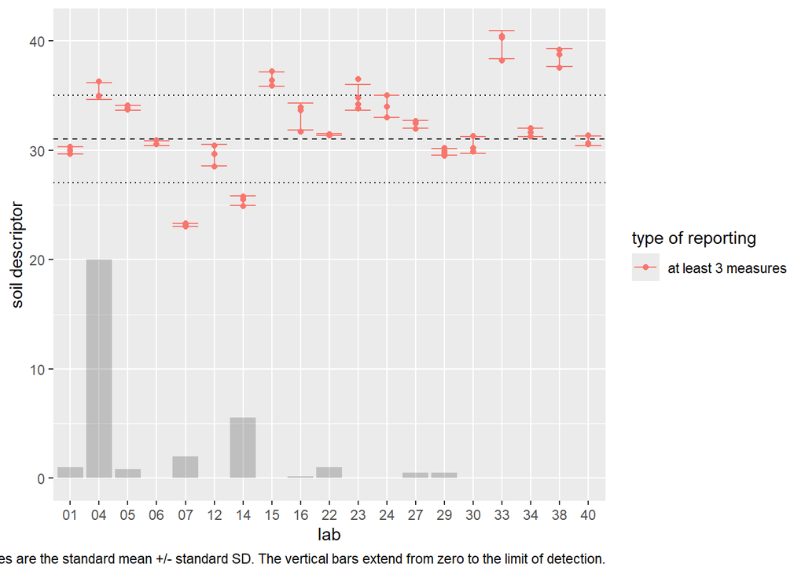

Figure 1: Raw data vizualisation. For labs reporting at least 3 measures we show the individual measurements and an error-bar extending to +/- 1 SD. For the labs reporting only the mean +/- SD, we show the mean and error-bar only.

```r
# standard value (reference measurement?)
standard    <- unique(data_ringtest_subst_clean$standard_extract_value)
standard_sd <- unique(data_ringtest_subst_clean$standard_extract_uncertain)

data_lod <- data_ringtest_subst_clean |>
  mutate(lod = as.numeric(gsub("< ", "", limit_determ))) |>
  distinct(lab_code, lod)

data_labs_ind <- data_ringtest_subst_clean |>
  filter(check == "3 measures") |>
  select(lab_code, contains("meas_")) |>
  select(-meas_unit) |>
  pivot_longer(
    paste0("meas_", 1:5), names_to = "replicate",
    values_to = "soil_descriptor"
  ) |>
  filter(!is.na(soil_descriptor)) |>
  mutate(
    .by = lab_code,
    meas_mean      = mean(soil_descriptor),
    meas_uncertain = sd(soil_descriptor)
  )

data_labs_aggr <- data_ringtest_subst_clean |>
  filter(check == "mean +/- SD") |>
  select(lab_code, meas_mean, meas_uncertain)

ggplot() +
  geom_hline(yintercept = standard, lty = 2) +
  geom_hline(yintercept = standard + c(-1, 1) * standard_sd, lty = 3) +
  geom_point(
    data = data_labs_ind,
    aes(lab_code, soil_descriptor, color = "at least 3 measures")
  ) +
  geom_errorbar(
    data = data_labs_ind,
    aes(lab_code, color = "at least 3 measures",
        ymin = meas_mean - meas_uncertain,
        ymax = meas_mean + meas_uncertain)
  ) +
  geom_point(
    data = data_labs_aggr,
    aes(lab_code, meas_mean, color = "mean +/- SD")
  ) +
  geom_errorbar(
    data = data_labs_aggr,
    aes(lab_code, color = "mean +/- SD",
        ymin = meas_mean - meas_uncertain,
        ymax = meas_mean + meas_uncertain)
  ) +
  geom_bar(data = data_lod, aes(lab_code, lod), stat = "identity",
           alpha = 0.3) +
  labs(x = "lab", y = "soil descriptor", color = "type of reporting",
       caption = "The horizontal dashed lines are the standard mean +/- standard SD. The vertical bars extend from zero to the limit of detection.")
```

## Proficiency test (ISO procedure)

How should we deal with this difference in reporting? We can’t use REML estimation, as this requires the raw data per replicate for all labs. We therefore use the classic approach based on cell-statistics.

We combine the cell-statistics from the two types of reporting. For labs reporting aggregated data, it is not reported on how many replicates this is based; we make the assumption of three replicates, but this needs verification.

```r
cell_stats <- rbind(
  # labs reporting individual data
  data_labs_ind |>
    rename(
      lab = lab_code,
      value = soil_descriptor
    ) |>
    mutate(level = 1) |>
    calc_cell_stats(),
  # labs reporting aggregated data
  data_labs_aggr |>
    rename(
      lab = lab_code,
      mean = meas_mean,
      sd = meas_uncertain
    ) |>
    mutate(
      level = 1,
      n = 3 # assumption: it is not reported on how many replicates it is based
    )
)

print(cell_stats)
```

```
   lab level n     mean         sd
1   06     1 3 30.63333 0.23094011
2   07     1 3 23.16667 0.15275252
3   04     1 3 35.38333 0.77693844
4   24     1 3 34.00000 1.00000000
5   30     1 3 30.46293 0.75556827
6   12     1 3 29.52637 0.98056952
7   40     1 3 30.83233 0.44189856
8   29     1 4 29.82500 0.29860788
9   15     1 3 36.50000 0.65574385
10  27     1 3 32.35402 0.37408876
11  34     1 3 31.61168 0.39125707
12  14     1 3 25.36129 0.44330258
13  01     1 3 29.97751 0.32013599
14  22     1 3 31.42667 0.05773503
15  38     1 3 38.47995 0.83091213
16  23     1 4 34.82500 1.18988795
17  16     1 3 33.07481 1.21513493
18  05     1 3 33.86667 0.20816660
19  33     1 3 39.64100 1.26226740
```

We calculate the Mandel $h$ and $k$ statistics to inspect for outlying means and variances, results are shown in Figure 2.

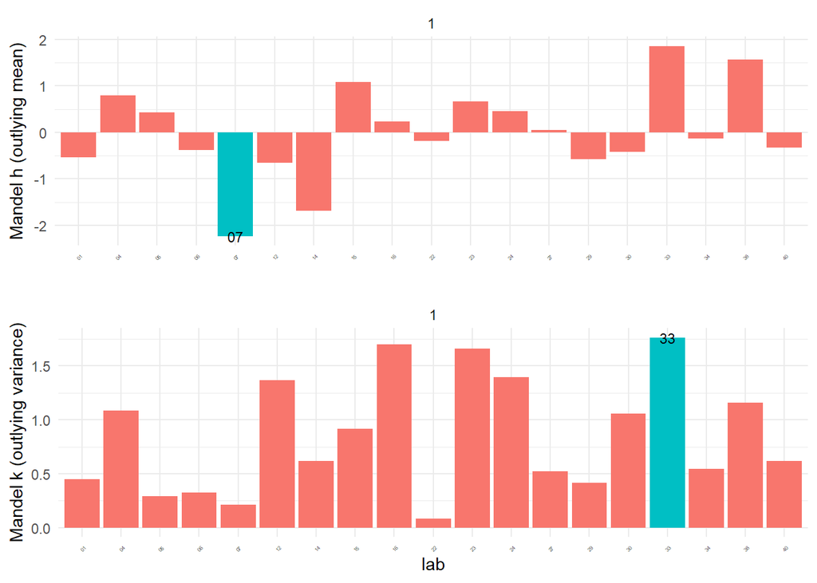

Figure 2: Mandel’s h & k statistics. Labs with outlying values at the 5% significance level are colored differently.

```r
calc_mandel_hk(cell_stats, alpha = 0.05) |>
  plot_mandel_hk()
```

Outlier removal should be an interactive process where the experts from the panel evaluate the data from a lab that is identified as outlier or straggler. For now I just follow the statistical ISO procedure where I retain stragglers and remove outliers. The ISO procedure mentions that only 2/9 of the data from a given level should be removed (8.3.6.2§2); which means for 19 labs only 4 can be removed; however, we previously removed already labs not meeting the reporting requirements, and I’m not sure if we have to count them as well? The final cleaned statistics per lab are shown in Figure 3.

```r
cell_stats_final <- outlier_removal_iso(cell_stats)
```

```
Iterative process to detect stragglers and outliers.
      Outliers are removed and stragglers retained.

 iteration 1:
[1] lab           level         n             cochran       grubbs_single
[6] grubbs_double
<0 rows> (or 0-length row.names)

 Outlier detection ended after 1 iterations.
```

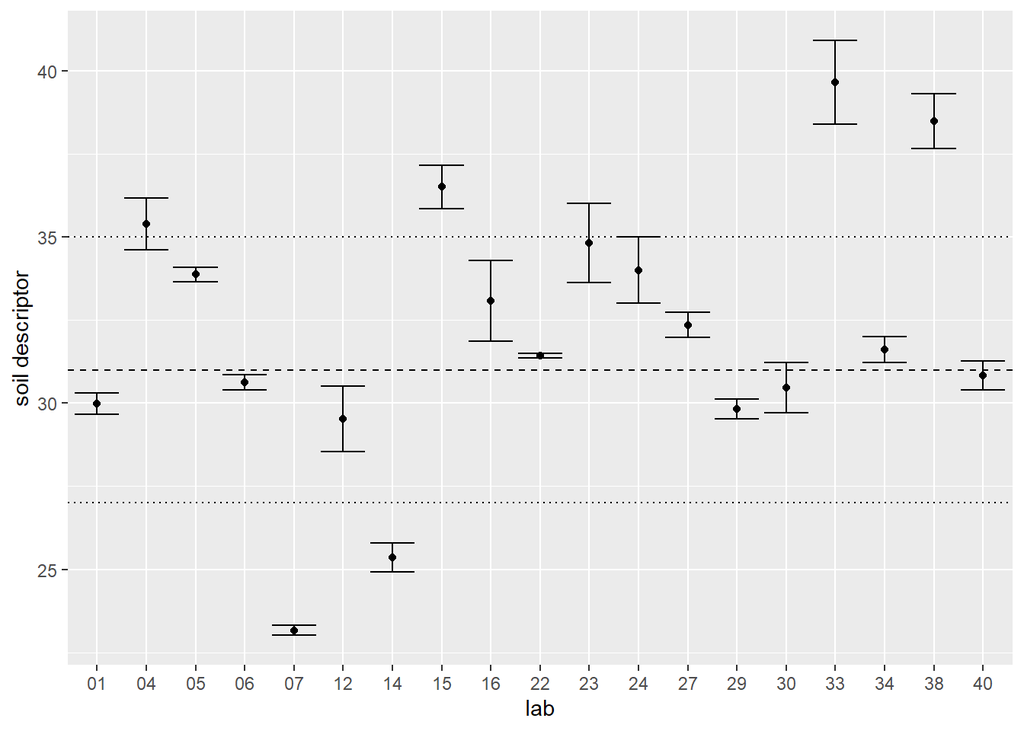

Figure 3: Aggregated statistics per lab after outlier removal.

```r
# standard value (reference measurement?)
standard    <- unique(data_ringtest_subst_clean$standard_extract_value)
standard_sd <- unique(data_ringtest_subst_clean$standard_extract_uncertain)

cell_stats_final |>
  ggplot(aes(lab, mean, ymin = mean - sd, ymax = mean + sd)) +
  geom_point() +
  geom_errorbar() +
  geom_hline(yintercept = standard, lty = 2) +
  geom_hline(yintercept = standard + c(-1, 1) * standard_sd, lty = 3) +
  labs(x = "lab", y = "soil descriptor")
```

We now calculate the cleand mean and the variance components (as SD):

- `m_hat` = cleaned mean
- `s_r` = repeatability SD
- `s_L` = inter-laboratory SD
- `s_R` = reproducibility SD

$$\sigma_R^2 = \sigma_r^2 + \sigma_L^2$$

```r
res <- ringtest(cell_stats_final) |>
  mutate(
    # add coefficients of variation
    cv_r = s_r / m_hat,
    cv_L = s_L / m_hat,
    cv_R = s_R / m_hat
  )
res
```

```
   p    m_hat       s_r      s_L      s_R level       cv_r      cv_L      cv_R
1 19 32.16094 0.7243775 3.963359 4.029012     1 0.02252352 0.1232352 0.1252765
```

The reported standard measures (`standard_extract_value` and `standard_extract_uncertainty`) are shown below for comparison. How are these values defined/calculated? (otherwise difficult to compare with results of the ringtest)

```r
data_ringtest_subst_clean |>
  distinct(standard_extract_value, standard_extract_uncertain)
```

```
# A tibble: 1 × 2
  standard_extract_value standard_extract_uncertain
                   <dbl>                      <dbl>
1                     31                          4
```